# Data analysis project using R

Fan Zou

2022-06-16

## Load packages

```r
library(tidyverse)
```

```r
library(ggplot2)
```

## Collect Data

We need to read the files. The most recent 12 month data have been downloaded to the local disk. The name of the files are compatible. They all start with the year-month plus a common suffix. We read the data into data frame one by one. Combine them into a single file.

```r
# the year of the files
x=c(202106:202112,202201:202205)
filename=paste("C:/Users/Fan/Documents/data analyst/course 8/clean data/",toString(x[1]),"-divvy-tripdata.csv",sep="")
print(filename)
```

```
## [1] "C:/Users/Fan/Documents/data analyst/course 8/clean data/202106-divvy-tripdata.csv"
```

```r
Bike_Data=read_csv(filename) # read the first file
for (i in 2:12) {
  filename=paste("C:/Users/Fan/Documents/data analyst/course 8/clean data/",toString(x[i]),"-divvy-tripdata.csv",sep="")
  print(filename)
  temp=read_csv(filename)  # read following files
  Bike_Data=rbind(Bike_Data,temp) # combine files into single data frame
}
```

```
## [1] "C:/Users/Fan/Documents/data analyst/course 8/clean data/202107-divvy-tripdata.csv"
## [1] "C:/Users/Fan/Documents/data analyst/course 8/clean data/202108-divvy-tripdata.csv"
## [1] "C:/Users/Fan/Documents/data analyst/course 8/clean data/202109-divvy-tripdata.csv"
## [1] "C:/Users/Fan/Documents/data analyst/course 8/clean data/202110-divvy-tripdata.csv"
## [1] "C:/Users/Fan/Documents/data analyst/course 8/clean data/202111-divvy-tripdata.csv"
## [1] "C:/Users/Fan/Documents/data analyst/course 8/clean data/202112-divvy-tripdata.csv"
## [1] "C:/Users/Fan/Documents/data analyst/course 8/clean data/202201-divvy-tripdata.csv"
## [1] "C:/Users/Fan/Documents/data analyst/course 8/clean data/202202-divvy-tripdata.csv"
## [1] "C:/Users/Fan/Documents/data analyst/course 8/clean data/202203-divvy-tripdata.csv"
## [1] "C:/Users/Fan/Documents/data analyst/course 8/clean data/202204-divvy-tripdata.csv"
## [1] "C:/Users/Fan/Documents/data analyst/course 8/clean data/202205-divvy-tripdata.csv"
```

```r
temp=c() # empty the variable to save space
```

## Prepare data

We are interested in the difference between annual membership users and casual users. The difference could be the time, duration, type fo bike and location of the usage.

Before we make any calculations, we take a look at the data summary to know what are recorded in the data.

```r
summary(Bike_Data)
```

```
##    ride_id          rideable_type        started_at
##  Length:5860776     Length:5860776     Min.   :2021-06-01 00:00:38.00
##  Class :character   Class :character   1st Qu.:2021-07-29 10:43:32.00
##  Mode  :character   Mode  :character   Median :2021-09-23 17:33:23.00
##                                        Mean   :2021-10-26 03:44:54.77
##                                        3rd Qu.:2022-01-14 10:59:12.75
##                                        Max.   :2022-05-31 23:59:56.00
##
##     ended_at                      start_station_name start_station_id
##  Min.   :2021-06-01 00:06:22.00   Length:5860776     Length:5860776
##  1st Qu.:2021-07-29 11:02:56.50   Class :character   Class :character
##  Median :2021-09-23 17:49:29.50   Mode  :character   Mode  :character
##  Mean   :2021-10-26 04:05:36.14
##  3rd Qu.:2022-01-14 11:14:48.50
##  Max.   :2022-06-02 11:35:01.00
##
##  end_station_name   end_station_id       start_lat       start_lng
##  Length:5860776     Length:5860776     Min.   :41.64   Min.   :-87.84
##  Class :character   Class :character   1st Qu.:41.88   1st Qu.:-87.66
##  Mode  :character   Mode  :character   Median :41.90   Median :-87.64
##                                        Mean   :41.90   Mean   :-87.65
##                                        3rd Qu.:41.93   3rd Qu.:-87.63
##                                        Max.   :45.64   Max.   :-73.80
##
##     end_lat         end_lng       member_casual
##  Min.   :41.39   Min.   :-88.97   Length:5860776
##  1st Qu.:41.88   1st Qu.:-87.66   Class :character
##  Median :41.90   Median :-87.64   Mode  :character
##  Mean   :41.90   Mean   :-87.65
##  3rd Qu.:41.93   3rd Qu.:-87.63
##  Max.   :42.17   Max.   :-87.49
##  NA's   :5036    NA's   :5036
```

We extract the day of the week from the time, and calculate the duration (length of the ride) for each trip.

```r
Bike_Data['Day_Week']=weekdays(Bike_Data$started_at)
Bike_Data['Duration']=Bike_Data$ended_at-Bike_Data$started_at
head(Bike_Data,5)
```

```
## # A tibble: 5 × 15
##   ride_id rideable_type started_at          ended_at            start_station_n…
##   <chr>   <chr>         <dttm>              <dttm>              <chr>
## 1 99FEC9… electric_bike 2021-06-13 14:31:28 2021-06-13 14:34:11 <NA>
## 2 06048D… electric_bike 2021-06-04 11:18:02 2021-06-04 11:24:19 <NA>
## 3 959806… electric_bike 2021-06-04 09:49:35 2021-06-04 09:55:34 <NA>
## 4 B03C0F… electric_bike 2021-06-03 19:56:05 2021-06-03 20:21:55 <NA>
## 5 B9EEA8… electric_bike 2021-06-04 14:05:51 2021-06-04 14:09:59 <NA>
## # … with 10 more variables: start_station_id <chr>, end_station_name <chr>,
## #   end_station_id <chr>, start_lat <dbl>, start_lng <dbl>, end_lat <dbl>,
## #   end_lng <dbl>, member_casual <chr>, Day_Week <chr>, Duration <drtn>
```

Based on the previous calculations, we find out the mean, max, and min values of the trips.

```r
Duration_Mean= mean(Bike_Data$Duration)
Duration_Max = max(Bike_Data$Duration)
Duration_Min = min(Bike_Data$Duration)
print(paste("Mean ride length is: ",Duration_Mean,sep=""))
```

```
## [1] "Mean ride length is: 1241.35633267676"
```

```r
print(paste("Max  ride length is: ",Duration_Max, sep=""))
```

```
## [1] "Max  ride length is: 3356649"
```

```r
print(paste("Min  ride length is: ",Duration_Min, sep=""))
```

```
## [1] "Min  ride length is: -3482"
```

## Clean data

We find that some data does not make sense. There are a few things we need to filter: * The end time should be larger than the start time. * The start date should be after 21-06-01. * Invalid date format that results to abnormal large duration. In total, 12657 rows are deleted.

```r
Bike_Data_Clean=filter(Bike_Data,format(Bike_Data$started_at,"%y-%m-%d")>="21-06-01" & Bike_Data$Duration>0 & Bike_Data$Duration<2e04)
Duration_Mean= mean(Bike_Data_Clean$Duration)
Duration_Max = max(Bike_Data_Clean$Duration)
Duration_Min = min(Bike_Data_Clean$Duration)
print(paste("Mean ride length is: ",Duration_Mean,sep=""))
```

```
## [1] "Mean ride length is: 1048.52033534202"
```

```r
print(paste("Max  ride length is: ",Duration_Max, sep=""))
```

```
## [1] "Max  ride length is: 19996"
```

```r
print(paste("Min  ride length is: ",Duration_Min, sep=""))
```

```
## [1] "Min  ride length is: 1"
```

We are interested in how the duration is distributed. Histogram can be used to show it. From this plot, we can check if our data cleaning works well.We find that the histogram has a poisson-like distribution which is normal for this type of data.

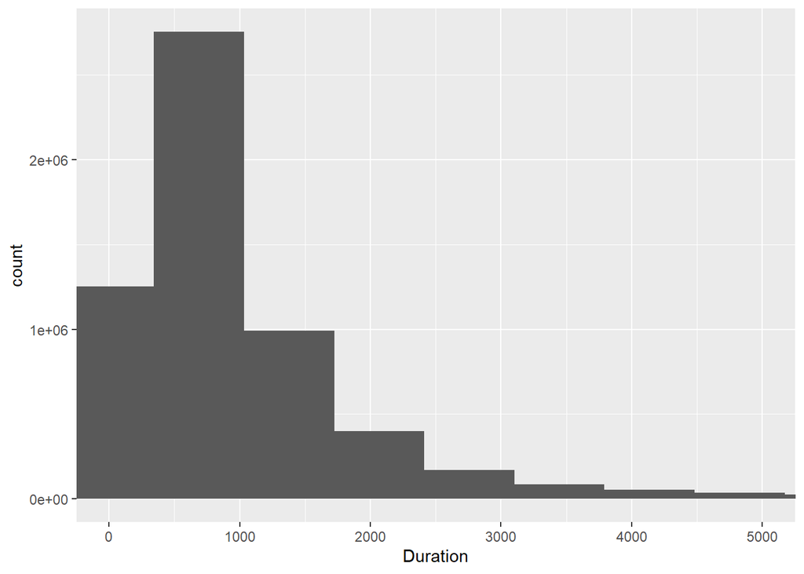

```r
ggplot(data = Bike_Data_Clean, aes(x = Duration)) +  geom_histogram() + coord_cartesian(xlim = c(0, 5000))
```

We check if only two types of members exist. This will help discover any typos in the membership column. From the results, the data is clean. We did the same thing to check if there are typos in the bike types. This column is also clean.

```r
unique(Bike_Data_Clean$member_casual)
```

```
## [1] "member" "casual"
```

```r
unique(Bike_Data_Clean$rideable_type)
```

```
## [1] "electric_bike" "classic_bike"  "docked_bike"
```

## Analyze data

#### First, we want to know what is the average duration.

We find that casual users have almost twice of the time than that of the members.

```r
Bike_Data_Clean %>%
  group_by(member_casual) %>%
  summarise(mean(Duration),sd(Duration))
```

```
## # A tibble: 2 × 3
##   member_casual `mean(Duration)` `sd(Duration)`
##   <chr>         <drtn>                    <dbl>
## 1 casual        1434.5676 secs            1673.
## 2 member         750.1298 secs             753.
```

We want to find out more details about how these numbers change over the day of week.We group the data by both membership and the day of Week. We find that there are ride time is longer during weekends for both members and casual users. The casual users always ride longer than members.

```r
Duration_Mean_Week = Bike_Data_Clean %>%
  group_by(member_casual,Day_Week) %>%
  summarise(t=mean(Duration),DurationSD=sd(Duration))
```

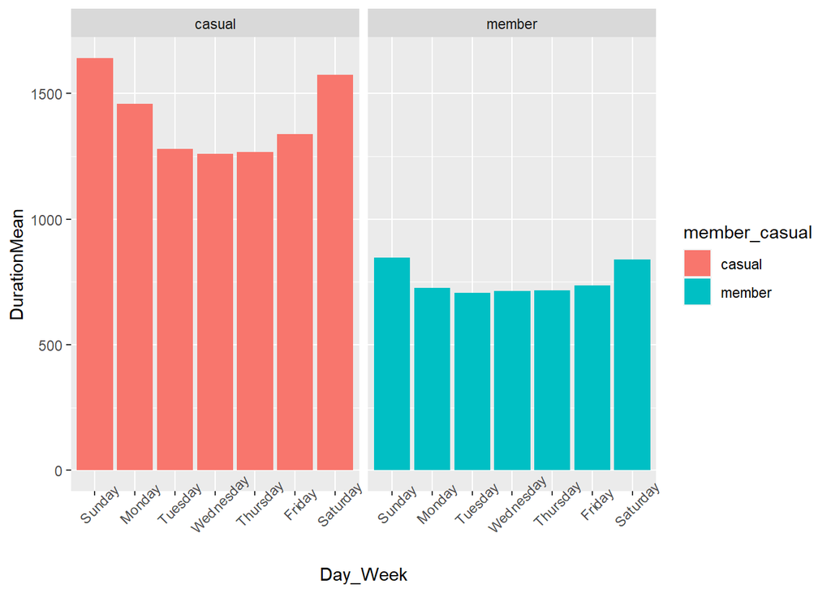

```r
Duration_Mean_Week$Day_Week=ordered(Duration_Mean_Week$Day_Week, levels=c("Sunday", "Monday", "Tuesday", "Wednesday", "Thursday", "Friday", "Saturday"))
Duration_Mean_Week["DurationMean"]=as.numeric(Duration_Mean_Week$t)
ggplot(data = Duration_Mean_Week,aes(x=Day_Week,y=DurationMean, fill=member_casual))+
  geom_bar(stat="identity") +
  theme(axis.text.x = element_text(angle = 45))+
  facet_wrap(~member_casual)
```

#### Second, We want to know the number of users by the day of week.

We find that casual users tends to ride the bike during the weekends, however members are more evenly distributed over the week.

```r
Counts_Users=Bike_Data_Clean %>%
  group_by(member_casual,Day_Week) %>%
  summarise(number_of_rides = n())
```

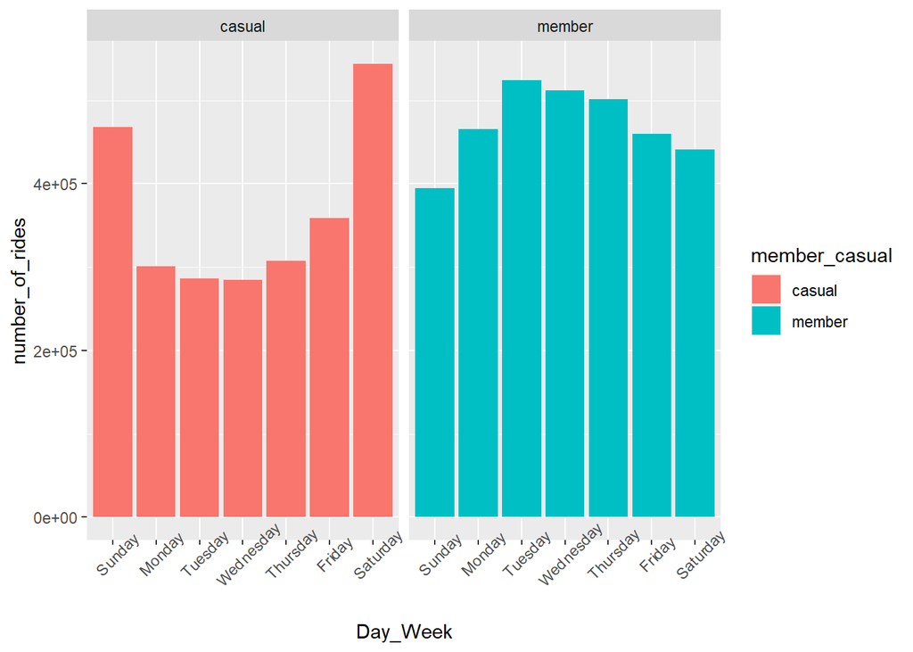

```r
Counts_Users$Day_Week=ordered(Counts_Users$Day_Week, levels=c("Sunday", "Monday", "Tuesday", "Wednesday", "Thursday", "Friday", "Saturday"))

ggplot(data = Counts_Users,aes(x=Day_Week,y=number_of_rides, fill=member_casual))+
  geom_bar(stat="identity") +
  theme(axis.text.x = element_text(angle = 45))+
  facet_wrap(~member_casual)
```

#### Third, we want to know what kind of bikes are used by casual users and members.

From the bar plot below, we find that both members and casual users mostly use classic bikes and electric bikes. But only casual users use docked bikes, although this percentage is small comparing to the other two types.

```r
Counts_Types=Bike_Data_Clean %>%
  group_by(member_casual,rideable_type) %>%
  summarise(number_of_rides = n())
```

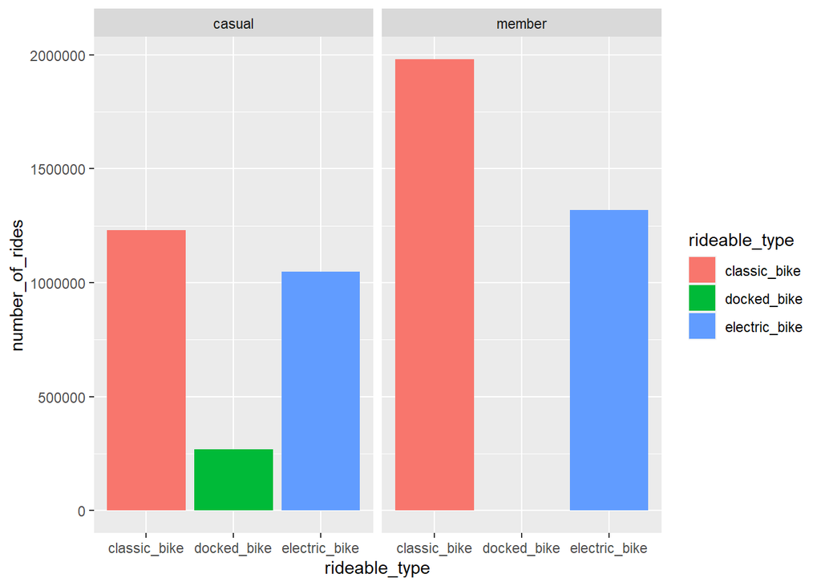

```r
ggplot(data = Counts_Types,aes(x=rideable_type,y=number_of_rides, fill=rideable_type))+
  geom_bar(stat="identity") +
  facet_wrap(~member_casual)
```